# Grafico Historico

João Gabriel

2023-05-30

```
## [1] "en_US.UTF-8"
```

# 1 Gráfico Histórico

Na parte C do trabalho nos é proposto programarmos um gráfico histórico usando ggplot2 usando como base o gráfico de Minard de 1812, que fala sobre a falha da operação de Napoleão para a invasão da Russia.

Essa atividade foi proposta para vermos o potencial do ggplot e suas diversas ferramentas, não apenas sua facilidade em fazer gráficos de linhas, barras ou dispersão, mas também gráficos mais complexos e com muitas variáveis.

## 1.1 A Tentativa de Invasão de Napoleão à Russia

O gráfico de Minard é uma visualização histórica da campanha de Napoleão na Rússia em 1812. Ele foi criado pelo estatístico Charles Joseph Minard e é um dos mais famosos e antigos exemplos de visualização de dados. O gráfico mostra o avanço do exército de Napoleão em direção a Moscou e sua derrota no retorno para a França.

A primeira parte mostra o avanço do exército francês em direção a Moscou. A linha turquesa mais grossa representa a marcha do exército em direção à Rússia, que começou com 422.000 soldados. A linha preta mais fina representa a retirada do exército, depois da invasão e captura de Moscou pelos franceses.

## 1.2 Gráficos separados

Aqui temos o gráfico dos vivos durante a ida e a volta dos franceses da Russia. Abaixo, temos a temperatura durante o inverno russo nesse período. Fiz mudanças nas cores dos gráficos, nas cores das linhas e também coloquei em negrito as legendas. Ademais, usei temas e coloquei, usando a biblioteca ggimage, a bandeira da frança no fundo do gráfico.

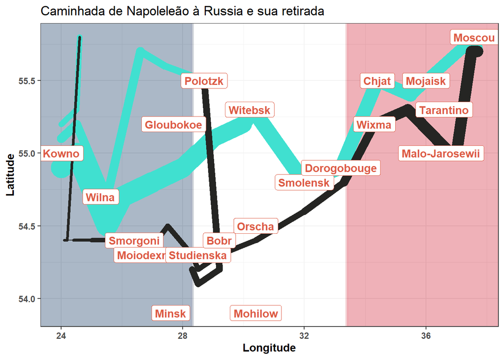

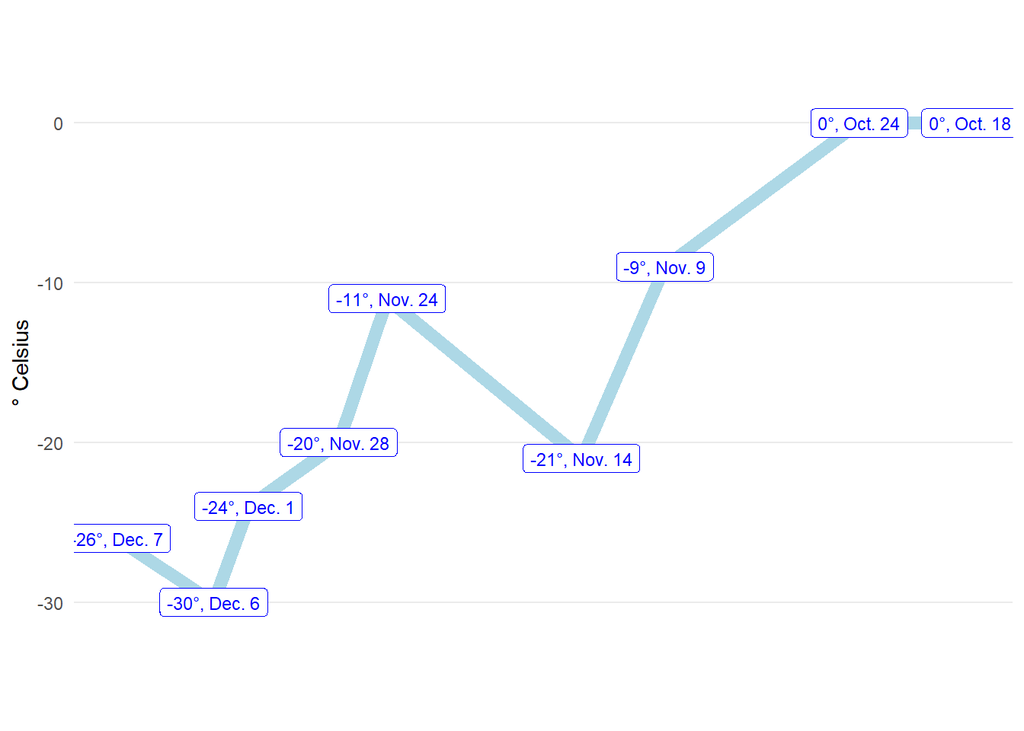

## 1.3 Gráficos unidos

Após feitos os dois gráficos e suas mudanças, usei o comando ggarrange da biblioteca ggpubr para fazer a ligação entre os dois gráficos e deixá-los numa mesma imagem, afivelando-os juntos.

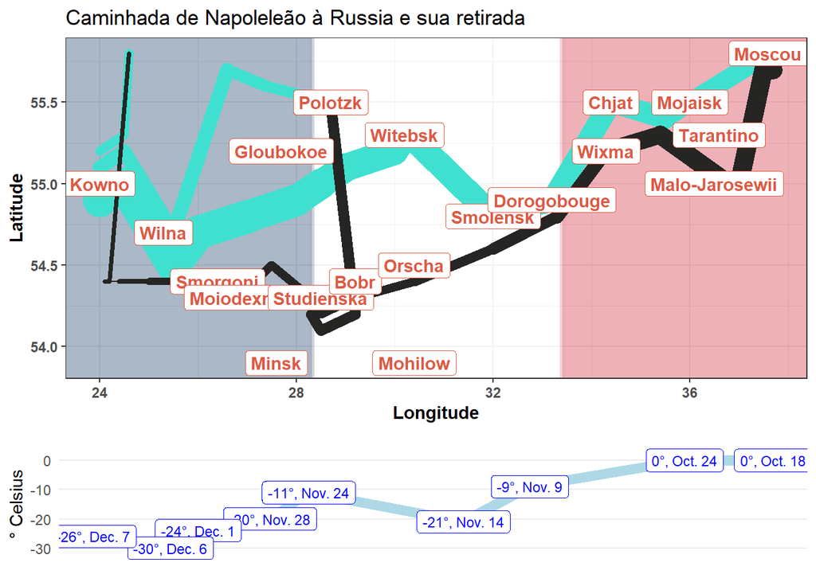

# 2 Conclusão

Essa visualização é uma das mais incríveis da história da estatística e eu achei ela muito interessante. O autor conseguiu exemplificar muitas variáveis com um simples gráfico, com muita clareza. Com ela, é possível receber muitíssima informação que seriam necessárias diversas páginas de texto para explicar. Muito bom ver também que o ggplot possui bons comandos para algo mais complexo.